# Chapter 2 - Summarizing Data

Sam Reeves

**Stats scores**. (2.33, p. 78) Below are the final exam scores of twenty introductory statistics students.

57, 66, 69, 71, 72, 73, 74, 77, 78, 78, 79, 79, 81, 81, 82, 83, 83, 88, 89, 94

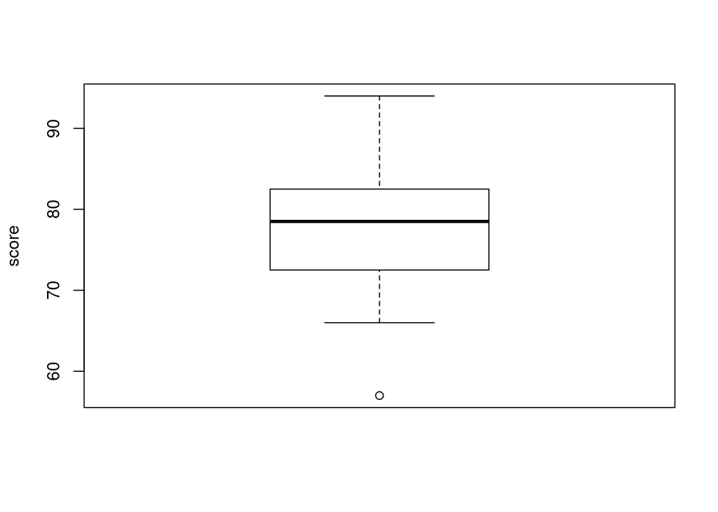

```r
boxplot(scores,
        ylab = 'score')
```

**Mix-and-match**. (2.10, p. 57) Describe the distribution in the histograms below and match them to the box plots.

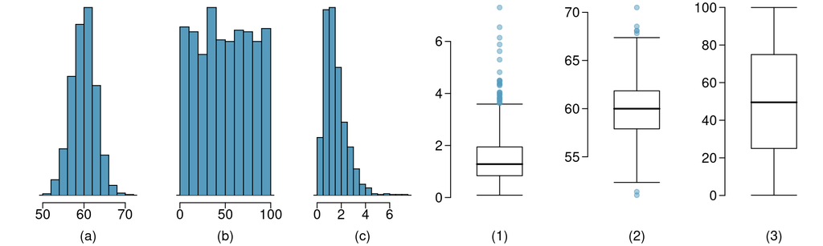

### (c)

1. monomodal, skewed right

**Distributions and appropriate statistics, Part II**. (2.16, p. 59) For each of the following, state whether you expect the distribution to be symmetric, right skewed, or left skewed. Also specify whether the mean or median would best represent a typical observation in the data, and whether the variability of observations would be best represented using the standard deviation or IQR. Explain your reasoning.

### (a)

Housing prices in a country where 25% of the houses cost below $350,000, 50% of the houses cost below $450,000, 75% of the houses cost below $1,000,000 and there are a meaningful number of houses that cost more than $6,000,000.

–

Median is best, because the significant number of observations with a higher-than-normal magnitude will offset the mean. This would be right skewed. Standard deviation would give a better picture of varying prices.

### (b)

Housing prices in a country where 25% of the houses cost below $300,000, 50% of the houses cost below $600,000, 75% of the houses cost below $900,000 and very few houses that cost more than $1,200,000.

–

### (c)

Number of alcoholic drinks consumed by college students in a given week. Assume that most of these students don’t drink since they are under 21 years old, and only a few drink excessively.

–

The mean score would be more useful in this case because there are potentially many observations which are zero. You would have a more accurate budget for your next party. IQR would help account for all the normies.

### (d)

Annual salaries of the employees at a Fortune 500 company where only a few high level executives earn much higher salaries than the all other employees.

–

In this case, median score would tell you a real value instead of a simulated one based on the entire populaiton. The data would be skewed hard right, and a standard deviation would be the most telling feature for scale.

**Heart transplants.** (2.26, p. 76) The Stanford University Heart Transplant Study was conducted to determine whether an experimental heart transplant program increased lifespan. Each patient entering the program was designated an official heart transplant candidate, meaning that he was gravely ill and would most likely benefit from a new heart. Some patients got a transplant and some did not. The variable *transplant* indicates which group the patients were in; patients in the treatment group got a transplant and those in the control group did not. Of the 34 patients in the control group, 30 died. Of the 69 people in the treatment group, 45 died. Another variable called *survived* was used to indicate whether or not the patient was alive at the end of the study.

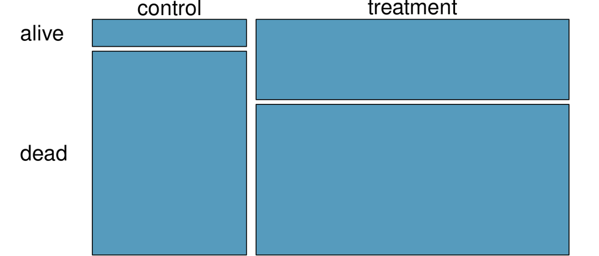

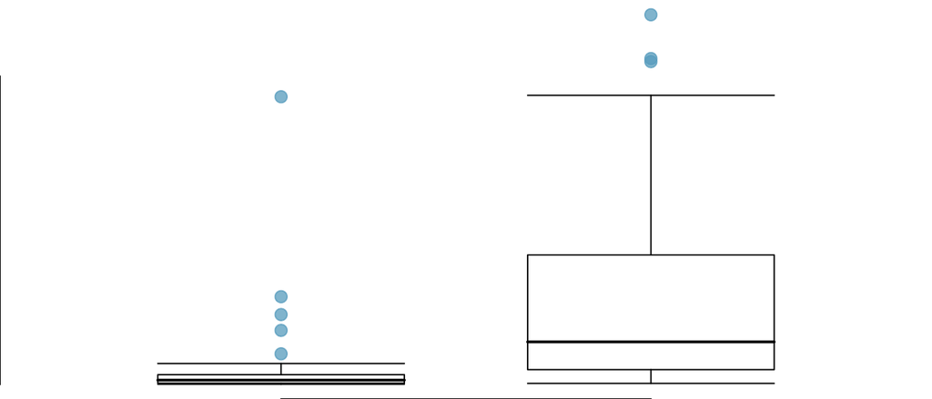

### (b) What do the box plots below suggest about the efficacy (effectiveness) of the heart transplant treatment.

They suggest that a robust portion of the candidates survived longer with treatment.

### (c) What proportion of patients in the treatment group and what proportion of patients in the control group died?

```r
t_death <- nrow(filter(heart_transplant,
                  transplant == 'treatment',
                  survived == 'dead'))
c_death <- nrow(filter(heart_transplant,
                  transplant == 'control',
                  survived == 'dead'))

cat("Treatment group deathtoll: ",
    t_death / sum(heart_transplant$transplant == 'treatment'))
```

```
## Treatment group deathtoll:  0.6521739
```

```r
cat("Control group deathtoll: ",
    c_death / sum(heart_transplant$transplant == 'control'))
```

```
## Control group deathtoll:  0.8823529
```

### (d) One approach for investigating whether or not the treatment is effective is to use a randomization technique.

1. What are the claims being tested?

Heart transplant positively affects survival rate in this group of patients who were already in extremely poor health.

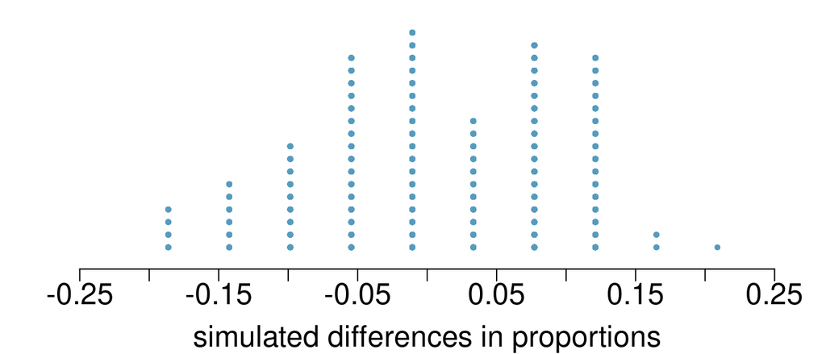